# Analysing the Causes of Heart Disease

Vidhi Rathod

28 April 2020

# Heart Disease prediction

Analysing Prediction power of different Machine learning algorithms on Heart disease data

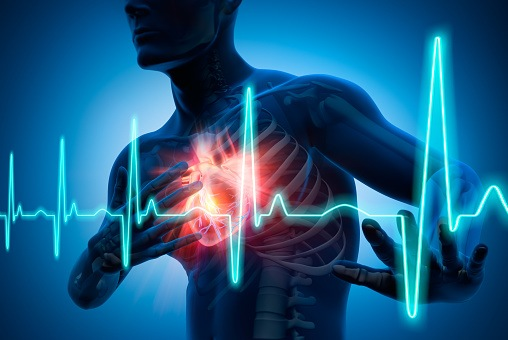

**About the data** The dataset used in this article is the Cleveland Heart Disease dataset taken from the UCI repository(http://archive.ics.uci.edu/ml/datasets/Heart+Disease). It originally contains 76 variables, but all published experiments refer to using 14 of them. The dataset consists of 303 observations. There are 14 columns in the dataset, which are described as follows:

## 1.0 Loading Libraries

## 1.1 Reading the data

```r
data_orig <- read.csv('heartdisease1.csv')

str(data_orig)
```

```
## 'data.frame':    303 obs. of  14 variables:
##  $ age     : int  63 37 41 56 57 57 56 44 52 57 ...
##  $ sex     : int  1 1 0 1 0 1 0 1 1 1 ...
##  $ cp      : int  3 2 1 1 0 0 1 1 2 2 ...
##  $ trestbps: int  145 130 130 120 120 140 140 120 172 150 ...
##  $ chol    : int  233 250 204 236 354 192 294 263 199 168 ...
##  $ fbs     : int  1 0 0 0 0 0 0 0 1 0 ...
##  $ restecg : int  0 1 0 1 1 1 0 1 1 1 ...
##  $ thalach : int  150 187 172 178 163 148 153 173 162 174 ...
##  $ exang   : int  0 0 0 0 1 0 0 0 0 0 ...
##  $ oldpeak : num  2.3 3.5 1.4 0.8 0.6 0.4 1.3 0 0.5 1.6 ...
##  $ slope   : int  0 0 2 2 2 1 1 2 2 2 ...
##  $ ca      : int  0 0 0 0 0 0 0 0 0 0 ...
##  $ thal    : int  1 2 2 2 2 1 2 3 3 2 ...
##  $ target  : int  1 1 1 1 1 1 1 1 1 1 ...
```

```r
head(data_orig)
```

```
##   age sex cp trestbps chol fbs restecg thalach exang oldpeak slope ca thal
## 1  63   1  3      145  233   1       0     150     0     2.3     0  0    1
## 2  37   1  2      130  250   0       1     187     0     3.5     0  0    2
## 3  41   0  1      130  204   0       0     172     0     1.4     2  0    2
## 4  56   1  1      120  236   0       1     178     0     0.8     2  0    2
## 5  57   0  0      120  354   0       1     163     1     0.6     2  0    2
## 6  57   1  0      140  192   0       1     148     0     0.4     1  0    1
##   target
## 1      1
## 2      1
## 3      1
## 4      1
## 5      1
## 6      1
```

## 2.0 Data Preperation

## 2.1 Data scrubbing

### 2.1.1 Scrubbing Function

Function to convert the class of variables:

```r
convert_class <- function(obj,types){
    for (i in 1:length(obj)){
        FUN <- switch(types[i],character = as.character,
                                   numeric = as.numeric,
                                   factor = as.factor)
        obj[,i] <- FUN(obj[,i])
    }
    obj
}
```

```r
data_orig<-rename(data_orig,heart_disease='target',age="age")

data_orig <- data_orig %>% rename() %>%
  mutate(sex = if_else(sex == 1, "male", "female"),
         fbs = if_else(fbs == 1, ">120", "<=120"),
         exang = if_else(exang == 1, "yes" ,"no"),
         cp = if_else(cp == 1, "atypical angina",
                      if_else(cp == 2, "non-anginal pain", "asymptotic")),
         restecg = if_else(restecg == 0, "normal",
                           if_else(restecg == 1, "abnormal", "definite")))

change_class <-c("numeric","factor","factor","numeric","numeric","factor","factor","numeric","factor","numeric","factor","factor","factor","numeric")

data_orig <- convert_class(data_orig,change_class)

label <- data.frame(
  age = "age in years",
  sex = "sex of the patient",
  cp = "chest pain type",
  trestbps = "resting blood pressure (in mm Hg on admission to the hospital)",
  chol = "serum cholestoral in mg/dl",
  fbs = "fasting blood sugar > 120 mg/dl",
  restecg = "resting electrocardiographic results",
  thalach = "maximum heart rate achieved",
  exang = "exercise induced angina",
  oldpeak = "ST depression induced by exercise relative to rest, a measure of abnormality in electrocardiograms",
  slope = "the slope of the peak exercise ST segment",
  ca = "number of major vessels (0-3) colored by flourosopy",
  thal = "3 = normal; 6 = fixed defect; 7 = reversable defect"
)


vtable::vtable(data_orig, labels = label, factor.limit = 0)
```

| Name | Class | Label | Values |
| --- | --- | --- | --- |
| age | numeric | age in years | Num: 29 to 77 |
| sex | factor | sex of the patient | ‘female’ ‘male’ |
| cp | factor | chest pain type | ‘asymptotic’ ‘atypical angina’ ‘non-anginal pain’ |
| trestbps | numeric | resting blood pressure (in mm Hg on admission to the hospital) | Num: 94 to 200 |
| chol | numeric | serum cholestoral in mg/dl | Num: 126 to 564 |
| fbs | factor | fasting blood sugar > 120 mg/dl | ‘<=120’ ‘>120’ |
| restecg | factor | resting electrocardiographic results | ‘abnormal’ ‘definite’ ‘normal’ |
| thalach | numeric | maximum heart rate achieved | Num: 71 to 202 |
| exang | factor | exercise induced angina | ‘no’ ‘yes’ |
| oldpeak | numeric | ST depression induced by exercise relative to rest, a measure of abnormality in electrocardiograms | Num: 0 to 6.2 |
| slope | factor | the slope of the peak exercise ST segment | ‘0’ ‘1’ ‘2’ |
| ca | factor | number of major vessels (0-3) colored by flourosopy | ‘0’ ‘1’ ‘2’ ‘3’ ‘4’ |
| thal | factor | 3 = normal; 6 = fixed defect; 7 = reversable defect | ‘0’ ‘1’ ‘2’ ‘3’ |
| heart_disease | numeric | NA | Num: 0 to 1 |

## 3.0 Data quality Check

```r
metadata<-t(introduce(data_orig))
colnames(metadata)<-"Values"
metadata
```

```
##                      Values
## rows                    303
## columns                  14
## discrete_columns          8
## continuous_columns        6
## all_missing_columns       0
## total_missing_values      0
## complete_rows           303
## total_observations     4242
## memory_usage          32592
```

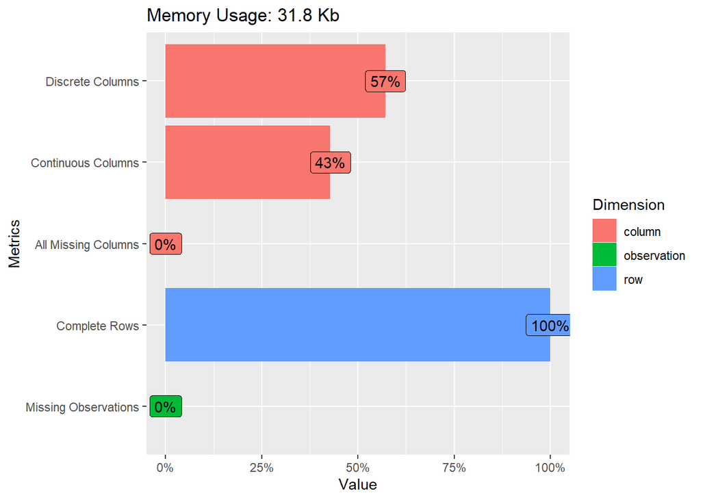

```r
plot_intro(data_orig)
```

**Plot the missing values**

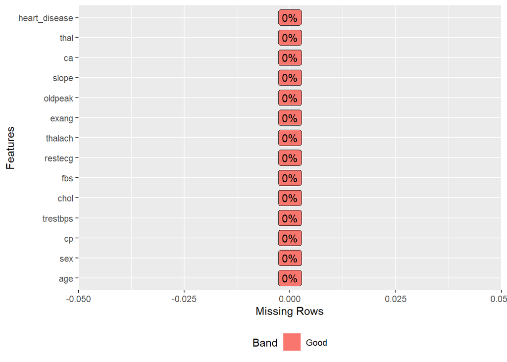

```r
plot_missing(data_orig)
```

* There are no missing values

## 4.0 Train test split

Splitting the data in 70:30 ratio

```r
set.seed(13263635)

train_percent <-0.70
index <- sample(nrow(data_orig),nrow(data_orig)*train_percent)
data <- data_orig[index,]
data_test <- data_orig[-index,]
```

**Summarizing the Training data**

```r
summary(data)
```

```
##       age            sex                     cp         trestbps
##  Min.   :29.00   female: 64   asymptotic      :114   Min.   : 94.0
##  1st Qu.:47.00   male  :148   atypical angina : 36   1st Qu.:120.0
##  Median :56.00                non-anginal pain: 62   Median :130.0
##  Mean   :54.33                                       Mean   :131.2
##  3rd Qu.:61.00                                       3rd Qu.:140.0
##  Max.   :74.00                                       Max.   :200.0
##       chol          fbs          restecg       thalach      exang
##  Min.   :126.0   <=120:180   abnormal:106   Min.   : 71.0   no :150
##  1st Qu.:208.0   >120 : 32   definite:  2   1st Qu.:138.0   yes: 62
##  Median :239.0               normal  :104   Median :154.0
##  Mean   :242.6                              Mean   :150.8
##  3rd Qu.:270.0                              3rd Qu.:168.0
##  Max.   :407.0                              Max.   :202.0
##     oldpeak       slope   ca      thal    heart_disease
##  Min.   :0.0000   0: 11   0:131   0:  2   Min.   :0.0000
##  1st Qu.:0.0000   1: 94   1: 37   1: 13   1st Qu.:0.0000
##  Median :0.6000   2:107   2: 29   2:119   Median :1.0000
##  Mean   :0.9892           3: 12   3: 78   Mean   :0.5943
##  3rd Qu.:1.6000           4:  3           3rd Qu.:1.0000
##  Max.   :4.4000                           Max.   :1.0000
```

## 5.0 Exploratory Data Analysis

**Chi-Square Test of Independence for categorical columns**

```r
#fetch numeric columns
catcols<-select_if(data, is.factor)
numcols<-select_if(data, is.numeric)

predictors<-catcols[,1:8]
response<-numcols$heart_disease

n<-ncol(predictors)
values<- vector(mode="numeric", length=n)
pvalues<- vector(mode="numeric", length=n)
name.pred<-vector(mode="character", length=n)


for(i in 1:ncol(predictors))
{
table(predictors[,i],response)
c<-chisq.test(predictors[,i],response)

pvalues[i]<-c$p.value
values[i]<-ifelse(round(pvalues[i],3)<0.05,1,0)
}

result<-data.frame(cbind(colnames(predictors),ifelse(round(pvalues,4)<0.001,"<0.001",round(pvalues,4)),values))
colnames(result)<-c("predictors","pvalues","Relationship")

result
```

```
##   predictors pvalues Relationship
## 1        sex  <0.001            1
## 2         cp  <0.001            1
## 3        fbs  0.8393            0
## 4    restecg  0.0032            1
## 5      exang  <0.001            1
## 6      slope  <0.001            1
## 7         ca  <0.001            1
## 8       thal  <0.001            1
```

**Interpretation** Except *fasting blood sugar* all predictors(categorical) variables seems to be related to Response.

**Correlation plot of numeric columns**

```r
#fetch numeric columns
numcols<-select_if(data_orig, is.numeric)

cor_heart <- cor(numcols)
cor_heart
```

```
##                      age    trestbps         chol      thalach     oldpeak
## age            1.0000000  0.27935091  0.213677957 -0.398521938  0.21001257
## trestbps       0.2793509  1.00000000  0.123174207 -0.046697728  0.19321647
## chol           0.2136780  0.12317421  1.000000000 -0.009939839  0.05395192
## thalach       -0.3985219 -0.04669773 -0.009939839  1.000000000 -0.34418695
## oldpeak        0.2100126  0.19321647  0.053951920 -0.344186948  1.00000000
## heart_disease -0.2254387 -0.14493113 -0.085239105  0.421740934 -0.43069600
##               heart_disease
## age             -0.22543872
## trestbps        -0.14493113
## chol            -0.08523911
## thalach          0.42174093
## oldpeak         -0.43069600
## heart_disease    1.00000000
```

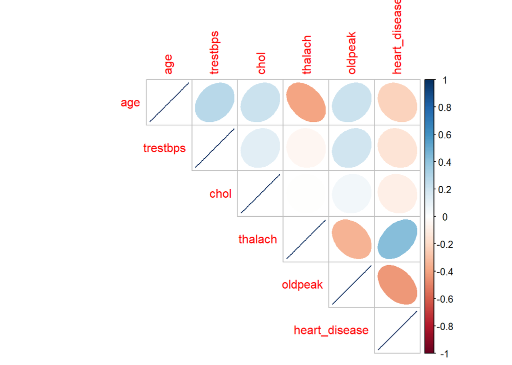

```r
#corr plot it
corrplot(cor_heart, method = "ellipse", type="upper",)
```

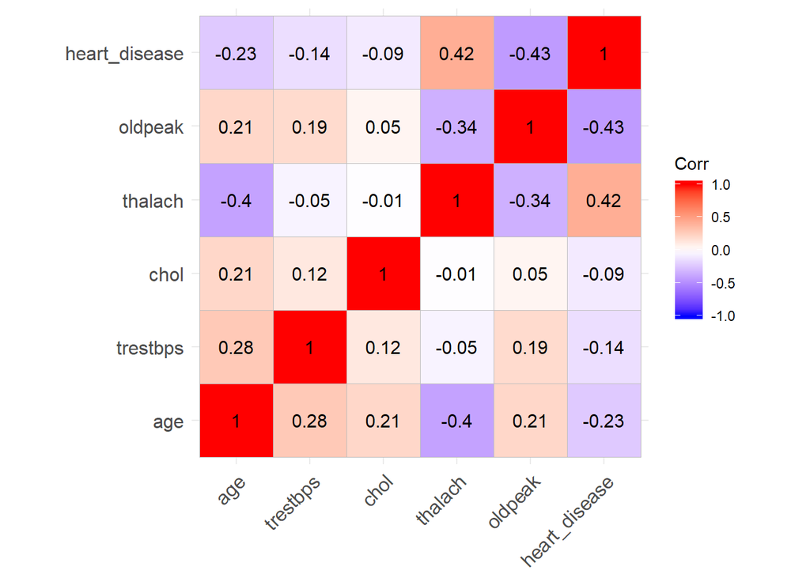

```r
#another
ggcorrplot(cor_heart,lab = T)
```

**Interpretation**

thalach: maximum heart rate achieved oldpeak: ST depression induced by exercise relative to rest, a measure of abnormality in electrocardiograms

seems to be correlated with response variable… However , thalach & oldpeak also show case substantial correlation amongst themselves.

chol & age are also somewhat correlated trestbps(resting blood pressure) & age also have substantial corelation.

All these correlation amongst predictors are somewhat smaller in magnitude. Therefore as of now we need not remove them from analysis.

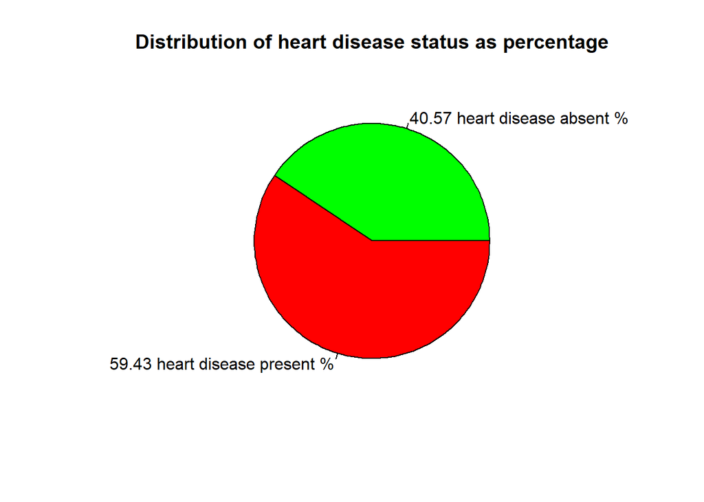

```r
present <- round((sum(as.numeric(data$heart_disease))*100)/nrow(data),2)
absent<- round((100 - present),2)

pie(table(data$heart_disease), col=c('green','red'),labels = c(paste(as.character(absent),'heart disease absent %'),paste(as.character(present), 'heart disease present %')),main = 'Distribution of heart disease status as percentage')
```

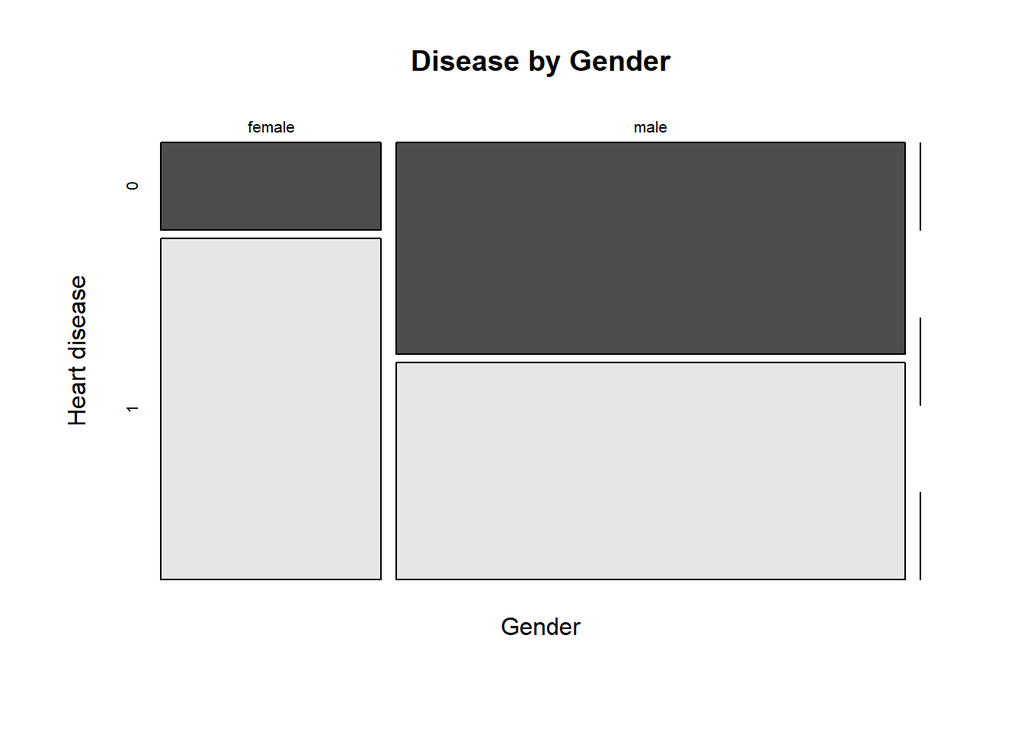

```r
levels(data$heart_disease) = c("No disease","Disease")
levels(data$sex) = c("female","male","")
mosaicplot(data$sex ~ data$heart_disease,
           main="Disease by Gender", shade=FALSE,color=TRUE,
           xlab="Gender", ylab="Heart disease")
```

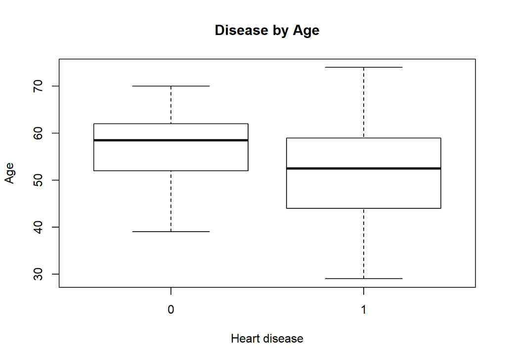

```r
boxplot(data$age ~ data$heart_disease,
        main="Disease by Age",
         ylab="Age",xlab="Heart disease")
```

```r
kable(head(data))  %>% kable_styling(bootstrap_options = c("striped", "hover", "responsive")) %>% scroll_box(width = "100%", height = "250px")
```

|  | age | sex | cp | trestbps | chol | fbs | restecg | thalach | exang | oldpeak | slope | ca | thal | heart_disease |
| --- | --- | --- | --- | --- | --- | --- | --- | --- | --- | --- | --- | --- | --- | --- |
| 100 | 53 | male | non-anginal pain | 130 | 246 | >120 | normal | 173 | no | 0.0 | 2 | 3 | 2 | 1 |
| 75 | 43 | female | non-anginal pain | 122 | 213 | <=120 | abnormal | 165 | no | 0.2 | 1 | 0 | 2 | 1 |
| 23 | 42 | male | asymptotic | 140 | 226 | <=120 | abnormal | 178 | no | 0.0 | 2 | 0 | 2 | 1 |
| 204 | 68 | male | non-anginal pain | 180 | 274 | >120 | normal | 150 | yes | 1.6 | 1 | 0 | 3 | 0 |
| 192 | 58 | male | asymptotic | 128 | 216 | <=120 | normal | 131 | yes | 2.2 | 1 | 3 | 3 | 0 |
| 257 | 58 | male | asymptotic | 128 | 259 | <=120 | normal | 130 | yes | 3.0 | 1 | 2 | 3 | 0 |

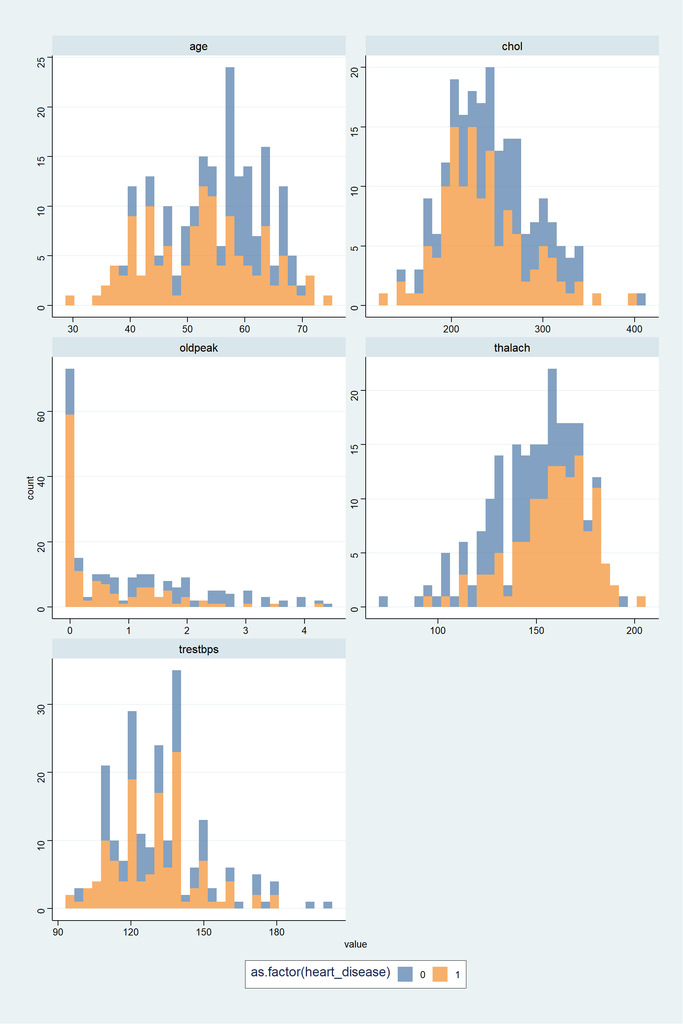

```r
num_features <- select_if(data, is.numeric) %>%  names()

data %>%
  dplyr::select(heart_disease, one_of(num_features))  %>%
  mutate(heart_disease=as.factor(heart_disease))%>%
  gather(key = key, value = value,-heart_disease)%>%
  ggplot(aes(x = value, fill = as.factor(heart_disease)))+
  geom_histogram(alpha = 0.7)+
  theme_stata()+
  facet_wrap(~ key, scales = 'free',ncol = 2,nrow = 4)+
  scale_fill_tableau()
```

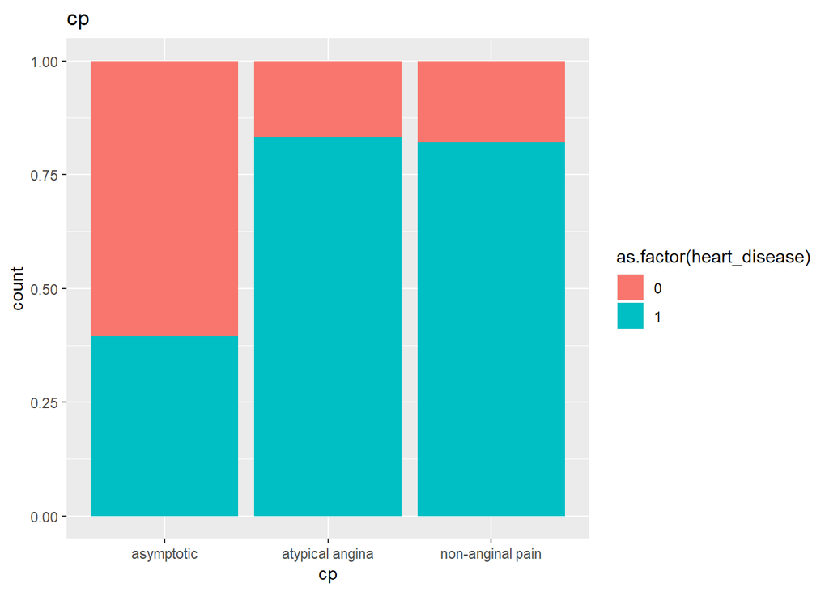

```r
ggplot(data, aes(cp, fill = as.factor(heart_disease)))+
  geom_bar(position = "fill")+
  ggtitle("cp")
```

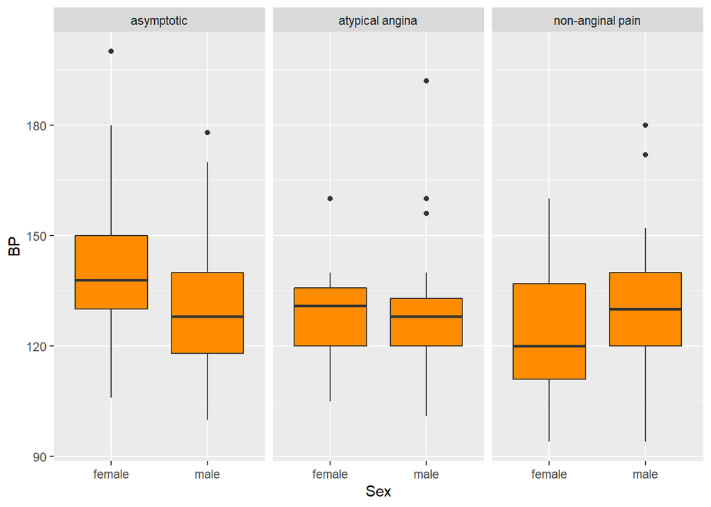

```r
data %>%
  ggplot(aes(x=sex,y=trestbps))+
  geom_boxplot(fill="darkorange")+
  xlab("Sex")+
  ylab("BP")+
  facet_grid(~cp)
```

## 6.0 Unsupervised Learning

### 6.1 K-means

```r
data$heart_disease<-as.factor(data$heart_disease)

numcols<-select_if(data, is.numeric)
uns_df <- scale(numcols)
distance <- get_dist(uns_df)
```

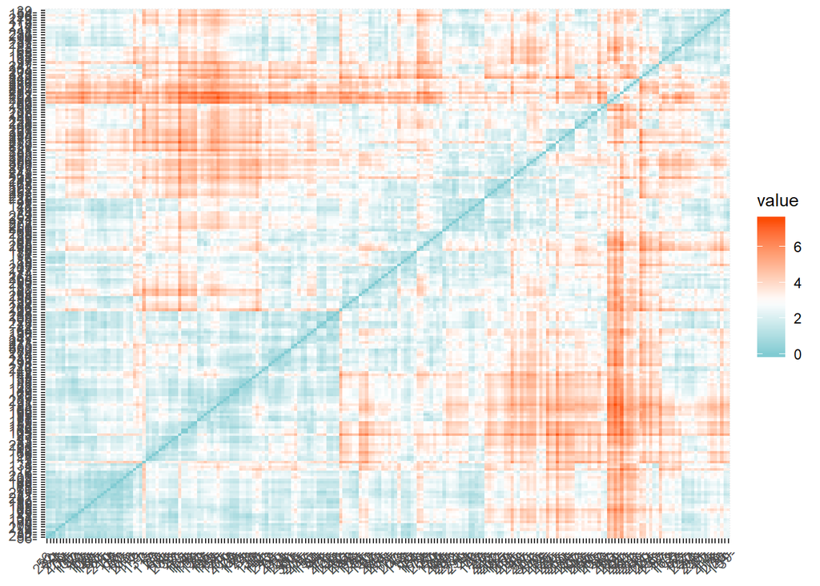

```r
fviz_dist(distance, gradient = list(low = "#00AFBB", mid = "white", high = "#FC4E07"))
```

```r
k2 <- kmeans(uns_df,
             center = 2,
             nstart = 25  )
#table(k2$cluster, dnn=("Clusters"))
k2
```

```
## K-means clustering with 2 clusters of sizes 113, 99
##
## Cluster means:
##          age   trestbps       chol    thalach    oldpeak
## 1 -0.6511378 -0.2758471 -0.3386202  0.5695421 -0.4314943
## 2  0.7432179  0.3148558  0.3865059 -0.6500835  0.4925136
##
## Clustering vector:
## 100  75  23 204 192 257 189 156  79  18 151  11 253  96  77 169 220 267
##   1   1   1   2   2   2   1   2   1   2   2   1   2   2   1   2   1   2
## 251 124   7  74 163 224 107  69   3 105 176 259  27  38 272 248 200 113
##   2   1   2   1   1   2   2   1   1   1   1   2   2   1   2   2   2   2
##  35 271 255 282 116  54 150  71 111  43 266 144 268 158  95 294  72 289
##   2   1   2   1   1   1   1   1   2   1   2   2   1   1   1   2   1   2
## 196  52 165 243  63 190 120 121  25 179 177 264  14   8 221 214 142 274
```

[output cut: 27 more lines]

Cluster means for each attribute is depicted in summary

**Visualization of Clusters**

*Plotiing Cluster using fviz_cluster*

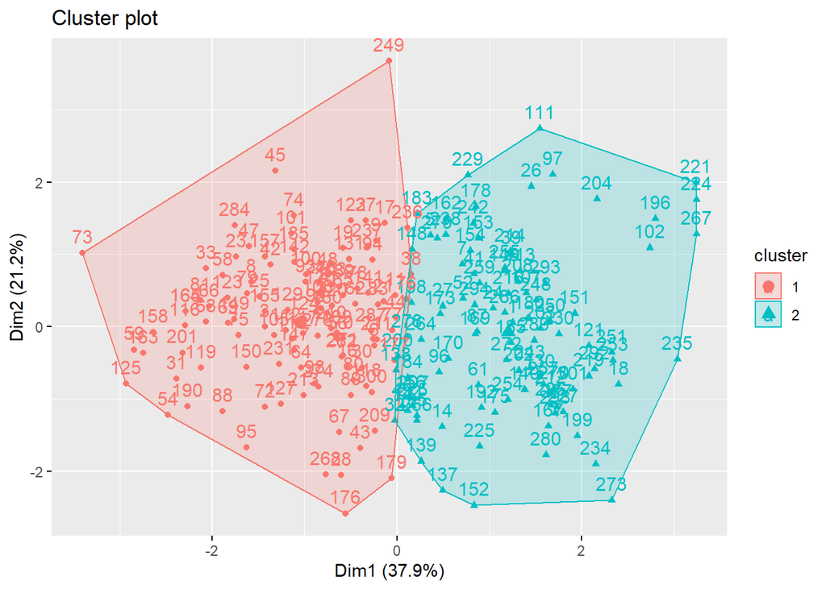

```r
fviz_cluster(k2, data = uns_df)
```

**Varying Visualizations by size**

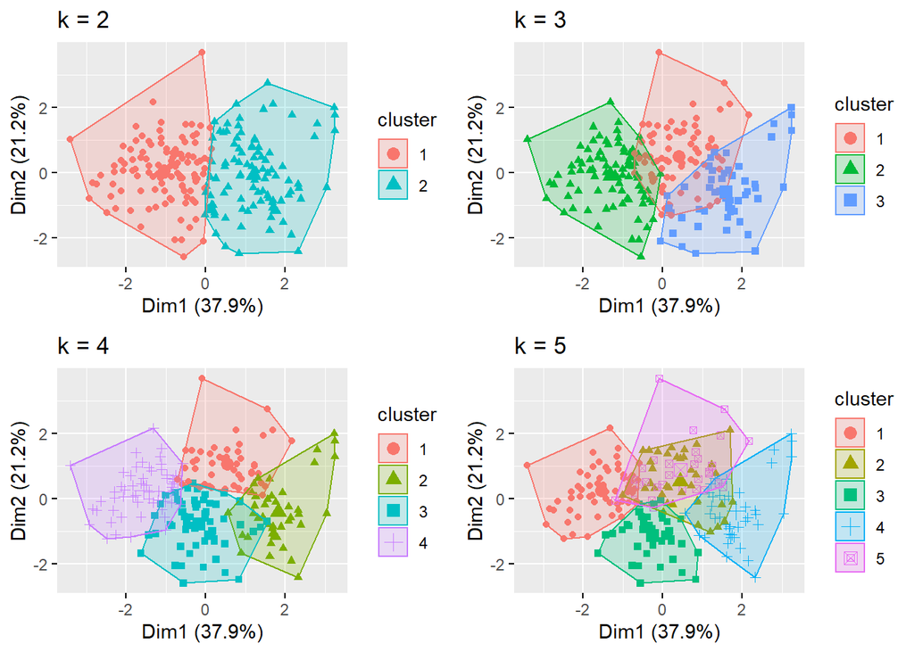

```r
# k2
k3 <- kmeans(uns_df, centers = 3, nstart = 25)
k4 <- kmeans(uns_df, centers = 4, nstart = 25)
k5 <- kmeans(uns_df, centers = 5, nstart = 25)

p1 <- fviz_cluster(k2, geom = "point", data = uns_df)+
  ggtitle("k = 2")
p2 <- fviz_cluster(k3, geom = "point", data = uns_df)+
  ggtitle("k = 3")
p3 <- fviz_cluster(k4, geom = "point", data = uns_df)+
  ggtitle("k = 4")
p4 <- fviz_cluster(k5, geom = "point", data = uns_df)+
  ggtitle("k = 5")

library(gridExtra)
grid.arrange(p1,p2,p3,p4, nrow = 2)
```

Although this visual assessment tells us where true dilineations occur (or do not occur such as clusters 2 & 4 in the k = 5 graph) between clusters, it does not tell us what the optimal number of clusters is.

**Determining Optimal Clusters**

As you may recall the analyst specifies the number of clusters to use; preferably the analyst would like to use the optimal number of clusters. To aid the analyst, the following explains the three most popular methods for determining the optimal clusters, which includes:

*Elbow method* Silhouette method *Gap statistic

##### (A) Elbow Method

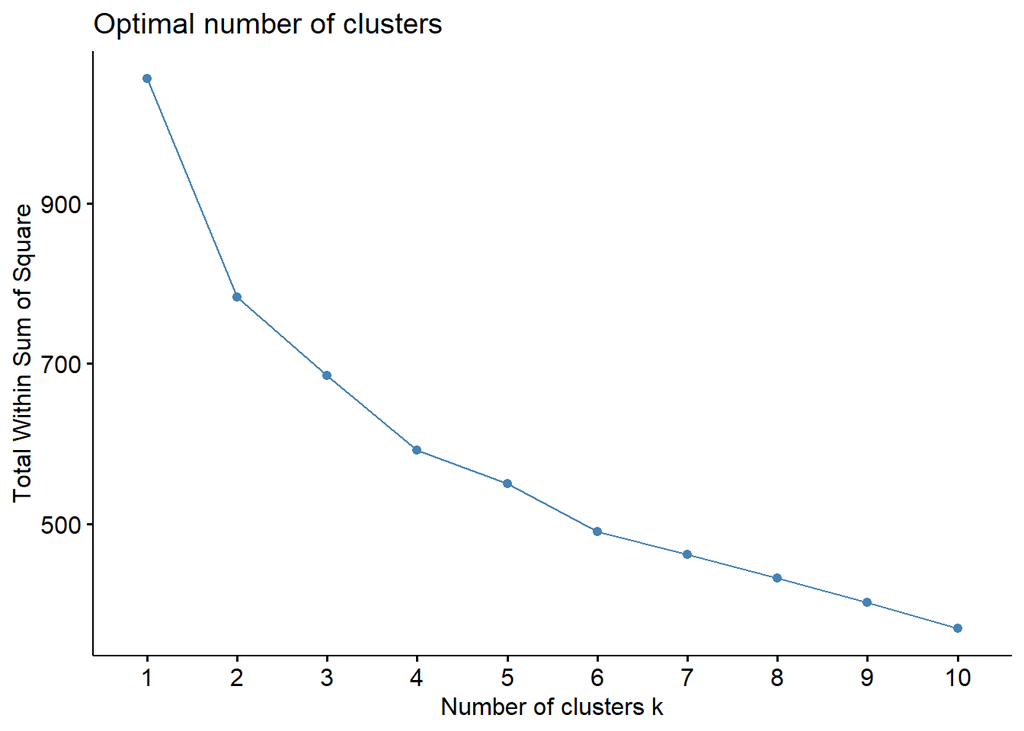

```r
#finding optimal number of clusters
set.seed(13263635)
fviz_nbclust(uns_df, kmeans, method = "wss")
```

##### (B) Silhouette Method

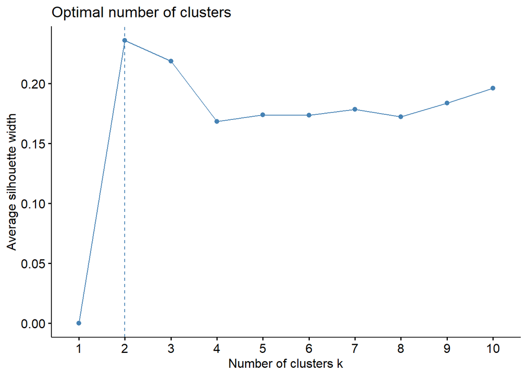

```r
#finding optimal number of clusters
set.seed(13263635)
fviz_nbclust(uns_df, kmeans, method = "silhouette")
```

##### (C) Compute gap statistic

```r
# compute gap statistic
set.seed(13263635)
gap_stat <- clusGap(uns_df, FUN = kmeans, nstart = 25,
                    K.max = 10, B = 50)
```

```r
# Print the result
print(gap_stat, method = "firstmax")
```

```
## Clustering Gap statistic ["clusGap"] from call:
## clusGap(x = uns_df, FUNcluster = kmeans, K.max = 10, B = 50,     nstart = 25)
## B=50 simulated reference sets, k = 1..10; spaceH0="scaledPCA"
##  --> Number of clusters (method 'firstmax'): 2
##           logW   E.logW       gap     SE.sim
##  [1,] 5.056204 5.511244 0.4550395 0.01762836
##  [2,] 4.902471 5.371684 0.4692130 0.01506240
##  [3,] 4.823181 5.274316 0.4511350 0.01747658
##  [4,] 4.757474 5.202080 0.4446056 0.01737994
##  [5,] 4.703252 5.145987 0.4427348 0.01643548
##  [6,] 4.659157 5.094961 0.4358043 0.01618537
##  [7,] 4.621819 5.050962 0.4291425 0.01613949
##  [8,] 4.573595 5.010673 0.4370777 0.01611355
##  [9,] 4.536792 4.975277 0.4384854 0.01602263
## [10,] 4.504008 4.943096 0.4390881 0.01617199
```

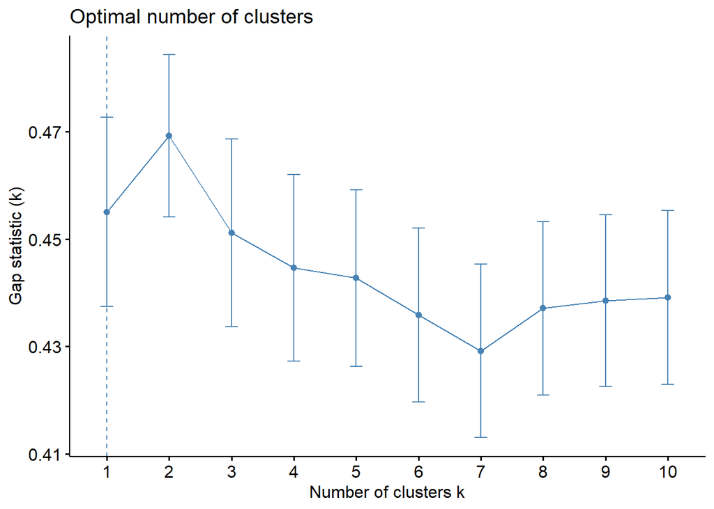

```r
#visualize
fviz_gap_stat(gap_stat)
```

**We choose k=2** As most algorithms suggested the same, Hence now we are assured to use 2 clusters.

```r
k2
```

```
## K-means clustering with 2 clusters of sizes 113, 99
##
## Cluster means:
##          age   trestbps       chol    thalach    oldpeak
## 1 -0.6511378 -0.2758471 -0.3386202  0.5695421 -0.4314943
## 2  0.7432179  0.3148558  0.3865059 -0.6500835  0.4925136
##
## Clustering vector:
## 100  75  23 204 192 257 189 156  79  18 151  11 253  96  77 169 220 267
##   1   1   1   2   2   2   1   2   1   2   2   1   2   2   1   2   1   2
## 251 124   7  74 163 224 107  69   3 105 176 259  27  38 272 248 200 113
##   2   1   2   1   1   2   2   1   1   1   1   2   2   1   2   2   2   2
##  35 271 255 282 116  54 150  71 111  43 266 144 268 158  95 294  72 289
##   2   1   2   1   1   1   1   1   2   1   2   2   1   1   1   2   1   2
## 196  52 165 243  63 190 120 121  25 179 177 264  14   8 221 214 142 274
```

[output cut: 27 more lines]

```r
#changed
datakmClustered<-data %>%
  mutate(Cluster = k2$cluster-1)
#2 is 1 and 1 is 0

#table(datakmClustered$heart_disease,datakmClustered$Cluster, dnn = c("ture","clustered"))
mcr<-mean(datakmClustered$heart_disease!=(datakmClustered$Cluster))
```

```r
outkmeans<-numcols %>%
  mutate(Cluster = k2$cluster) %>%
  group_by(Cluster) %>%
  summarise_all("mean")

kable(outkmeans)  %>%
  kable_styling(bootstrap_options = c("striped", "hover", "responsive"),
                font_size = 12, position = "left", full_width = FALSE)
```

| Cluster | age | trestbps | chol | thalach | oldpeak |
| --- | --- | --- | --- | --- | --- |
| 1 | 48.42478 | 126.0619 | 226.4425 | 163.5487 | 0.5035398 |
| 2 | 61.08081 | 137.1010 | 260.9697 | 136.1414 | 1.5434343 |

**Interpretation** The mean of all predictors(continious) appear to be different for both the clusters created.

### 6.2 Hierachical Clustering

Here we have implementd hierachical clustering for categorical & continious variables

The clustering process itself contains 3 distinctive steps:

*Calculating dissimilarity matrix - is arguably the most important decision in clustering, and all your further steps are going to be based on the dissimilarity matrix you’ve made.* Choosing the clustering method *Assessing clusters

Data types differences are important as dissimilarity matrix is based on distances between individual data points. While it is quite easy to imagine distances between numerical data points (Eucledian distances), categorical data (factors in R) does not seem as obvious. In order to calculate a dissimilarity matrix in this case, you would go for something called Gower distance

```r
tree <- hclustvar(numcols, catcols)
```

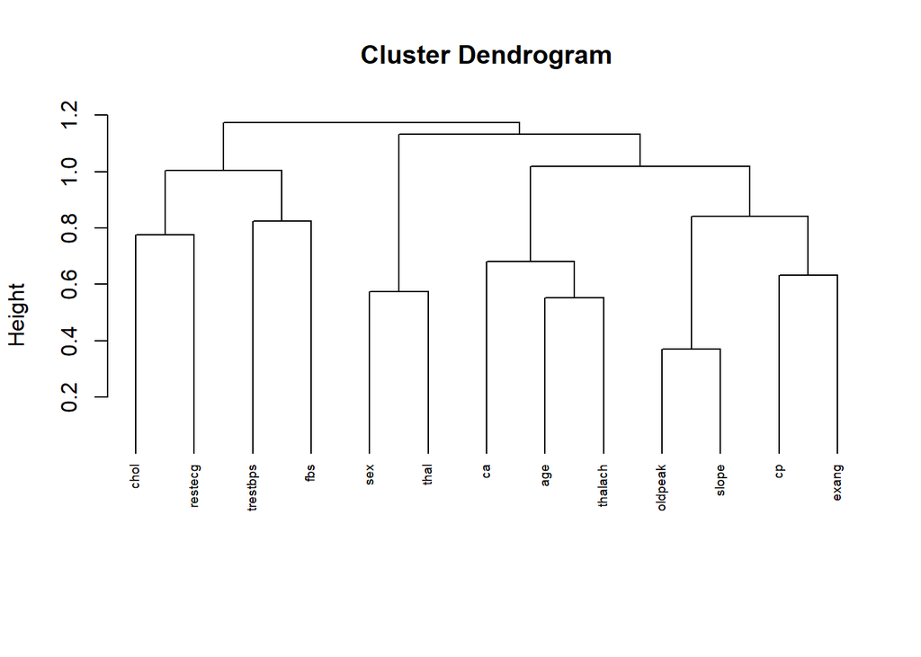

```r
plot(tree, cex = 0.6)
```

```r
#rect.hclust(tree, k = 4, border = 2:4)
```

**Stablity check using bootstraping**

Evaluates the stability of partitions obtained from a hierarchy of p variables. This hierarchy is performed with hclustvar and the stability of the partitions of 2 to p-1 clusters is evaluated with a bootstrap approach. The boostrap approch is the following: hclustvar is applied to B boostrap samples of the n rows. The partitions of 2 to p-1 clusters obtained from the B bootstrap hierarchies are compared with the partitions from the initial hierarchy . The mean of the corrected Rand indices is plotted according to the number of clusters. This graphical representation helps in the determination of a suitable numbers of clusters

```r
stab <- stability(tree, B=50) # "B=50" refers to the number of bootstrap samples to use in the estimation.
```

[figure not shown]

**Using Dissimilarity matrix**

“Gower’s distance” is chosen by metric “gower” or automatically if some columns of x are not numeric. Also known as Gower’s coefficient (1971), expressed as a dissimilarity, this implies that a particular standardisation will be applied to each variable, and the “distance” between two units is the sum of all the variable-specific distances

```r
d <- daisy(data[,-14], metric="gower")
fit <- hclust(d=d, method="ward.D")    # Also try: method="ward.D"
# Cut tree into 4 groups
sub_grp <- cutree(fit, k = 2)
# Number of members in each cluster
table(sub_grp)
```

```
## sub_grp
##   1   2
## 153  59
```

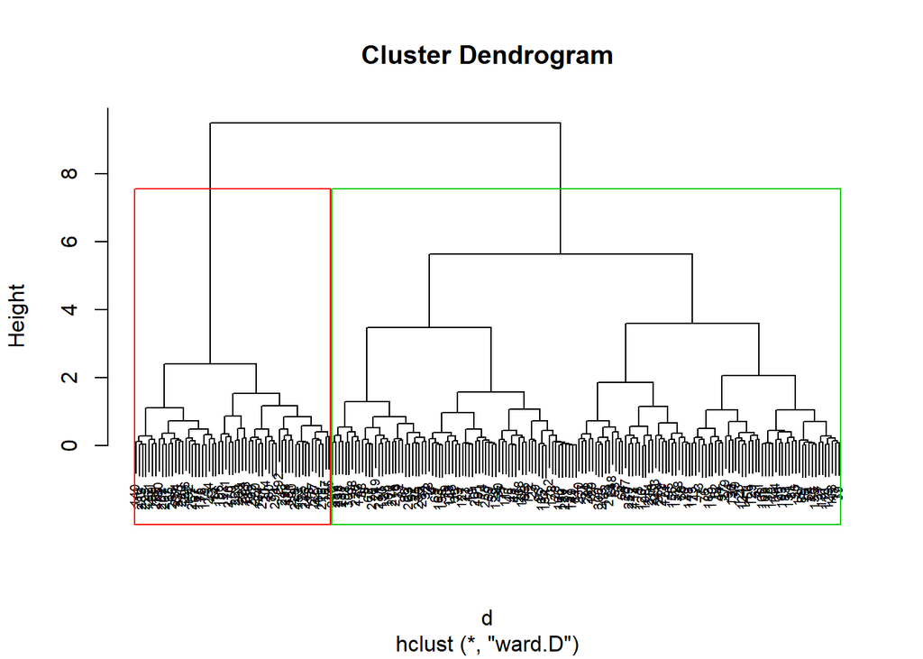

```r
plot(fit, cex = 0.6)
rect.hclust(fit, k = 2, border = 2:4)
```

Adding the clusters to our traing data

```r
HCdata<-data %>%
  mutate(HCcluster = sub_grp)
```

Misclassification calculation

```r
HCdata$HCcluster[HCdata$HCcluster==2] <- 0
#table(HCdata$heart_disease,HCdata$HCcluster, dnn = c("ture","clustered"))
mcr<-mean(HCdata$heart_disease!=HCdata$HCcluster)
```

### 6.3 PCA

Model the numeric columns to PCA model, It is always performed on a symmetric correlation or covariance matrix. This means the matrix should be numeric and have standardized data.

```r
datapca<-data[,1:13]
dt<-dummy.data.frame(datapca)
colnames(dt)
```

```
##  [1] "age"                "sexfemale"          "sexmale"
##  [4] "cpasymptotic"       "cpatypical angina"  "cpnon-anginal pain"
##  [7] "trestbps"           "chol"               "fbs<=120"
## [10] "fbs>120"            "restecgabnormal"    "restecgdefinite"
## [13] "restecgnormal"      "thalach"            "exangno"
## [16] "exangyes"           "oldpeak"            "slope0"
## [19] "slope1"             "slope2"             "ca0"
## [22] "ca1"                "ca2"                "ca3"
## [25] "ca4"                "thal0"              "thal1"
## [28] "thal2"              "thal3"
```

```r
pca <- prcomp(dt, scale = TRUE)
pca
```

```
## Standard deviations (1, .., p=29):
##  [1] 2.246490e+00 1.580613e+00 1.515313e+00 1.388388e+00 1.321554e+00
##  [6] 1.308160e+00 1.272534e+00 1.189638e+00 1.144859e+00 1.114827e+00
## [11] 1.017576e+00 1.006372e+00 9.945358e-01 9.501946e-01 9.079434e-01
## [16] 8.639616e-01 8.510374e-01 7.905021e-01 7.822965e-01 6.214353e-01
## [21] 5.717560e-01 9.976420e-16 6.426039e-16 5.797642e-16 5.454954e-16
## [26] 4.571771e-16 4.554836e-16 3.202758e-16 1.116381e-16
##
## Rotation (n x k) = (29 x 29):
##                              PC1           PC2          PC3         PC4
## age                 0.2040227737 -1.833293e-01  0.094779873 -0.13731378
## sexfemale          -0.1413086011 -5.394177e-01 -0.039906990 -0.10547773
## sexmale             0.1413086011  5.394177e-01  0.039906990  0.10547773
## cpasymptotic        0.2942003135 -2.461245e-02 -0.124389538  0.04018123
## cpatypical angina  -0.1600597333 -5.511576e-06  0.032650698  0.05734463
## cpnon-anginal pain -0.1903397143  2.698063e-02  0.109385163 -0.09137243
## trestbps            0.0935479157 -1.204104e-01  0.222487435  0.12005801
## chol                0.0849067274 -2.803531e-01 -0.029034968  0.08955058
## fbs<=120           -0.0554027651  2.904020e-02 -0.591801533  0.18297854
## fbs>120             0.0554027651 -2.904020e-02  0.591801533 -0.18297854
## restecgabnormal    -0.1736418581  7.301015e-02 -0.134795878 -0.54120573
## restecgdefinite     0.0625879247 -1.361349e-01 -0.006726700  0.07124934
## restecgnormal       0.1615699524 -4.669831e-02  0.136120641  0.52752438
## thalach            -0.2642768993  1.226385e-01  0.027373082  0.15232430
## exangno            -0.2662813236  5.344106e-02  0.103829439  0.13787861
## exangyes            0.2662813236 -5.344106e-02 -0.103829439 -0.13787861
## oldpeak             0.3018129056 -1.014582e-01 -0.013299747  0.02003847
## slope0              0.1129508182 -6.226086e-02  0.230618976  0.14454194
## slope1              0.2404813692 -1.326143e-01 -0.214508548 -0.02652619
## slope2             -0.2890528978  1.593875e-01  0.110832619 -0.03776438
## ca0                -0.1863277619 -2.539686e-02 -0.017259545  0.31810714
## ca1                 0.0801730543  5.412041e-02 -0.100692516 -0.18736497
## ca2                 0.1440907534 -5.350135e-02  0.095050946 -0.17389422
## ca3                 0.0880689230 -1.975906e-02  0.062237127 -0.05200381
## ca4                -0.0826325459  1.248690e-01 -0.003714119 -0.09886796
## thal0              -0.0003292663 -1.790613e-02  0.071960874 -0.04474856
## thal1               0.1071281011  3.217524e-03  0.087323525  0.08306735
## thal2              -0.2887953143 -2.791867e-01 -0.032234467  0.04175985
## thal3               0.2439394038  2.892717e-01 -0.024699924 -0.07532716
##                            PC5          PC6           PC7          PC8
```

[output cut: 194 more lines]

```
## exangno             1.582416e-02
## exangyes            1.582416e-02
## oldpeak             1.387779e-17
## slope0              2.562918e-01
## slope1              5.740442e-01
## slope2              5.777327e-01
## ca0                -1.313575e-01
## ca1                -1.026117e-01
## ca2                -9.289694e-02
## ca3                -6.247158e-02
## ca4                -3.193086e-02
## thal0              -6.833711e-03
## thal1              -1.696017e-02
## thal2              -3.507898e-02
## thal3              -3.409037e-02
```

```r
pcaCharts <- function(x) {
    x.var <- x$sdev ^ 2
    x.pvar <- x.var/sum(x.var)
    print("proportions of variance:")
    print(x.pvar)

    par(mfrow=c(2,2))
    plot(x.pvar,xlab="Principal component", ylab="Proportion of variance explained", ylim=c(0,1), type='b')
    plot(cumsum(x.pvar),xlab="Principal component", ylab="Cumulative Proportion of variance explained", ylim=c(0,1), type='b')
    screeplot(x)
    screeplot(x,type="l")
    par(mfrow=c(1,1))
}
```

```r
summ<-summary(pca)
summ
```

```
## Importance of components:
##                          PC1     PC2     PC3     PC4     PC5     PC6
## Standard deviation     2.246 1.58061 1.51531 1.38839 1.32155 1.30816
## Proportion of Variance 0.174 0.08615 0.07918 0.06647 0.06022 0.05901
## Cumulative Proportion  0.174 0.26017 0.33935 0.40582 0.46605 0.52506
##                            PC7    PC8    PC9    PC10    PC11    PC12
## Standard deviation     1.27253 1.1896 1.1449 1.11483 1.01758 1.00637
## Proportion of Variance 0.05584 0.0488 0.0452 0.04286 0.03571 0.03492
## Cumulative Proportion  0.58090 0.6297 0.6749 0.71775 0.75346 0.78838
##                           PC13    PC14    PC15    PC16    PC17    PC18
## Standard deviation     0.99454 0.95019 0.90794 0.86396 0.85104 0.79050
## Proportion of Variance 0.03411 0.03113 0.02843 0.02574 0.02497 0.02155
## Cumulative Proportion  0.82249 0.85362 0.88205 0.90779 0.93276 0.95431
##                          PC19    PC20    PC21      PC22      PC23
## Standard deviation     0.7823 0.62144 0.57176 9.976e-16 6.426e-16
## Proportion of Variance 0.0211 0.01332 0.01127 0.000e+00 0.000e+00
## Cumulative Proportion  0.9754 0.98873 1.00000 1.000e+00 1.000e+00
##                             PC24      PC25      PC26      PC27      PC28
## Standard deviation     5.798e-16 5.455e-16 4.572e-16 4.555e-16 3.203e-16
## Proportion of Variance 0.000e+00 0.000e+00 0.000e+00 0.000e+00 0.000e+00
## Cumulative Proportion  1.000e+00 1.000e+00 1.000e+00 1.000e+00 1.000e+00
##                             PC29
## Standard deviation     1.116e-16
## Proportion of Variance 0.000e+00
## Cumulative Proportion  1.000e+00
```

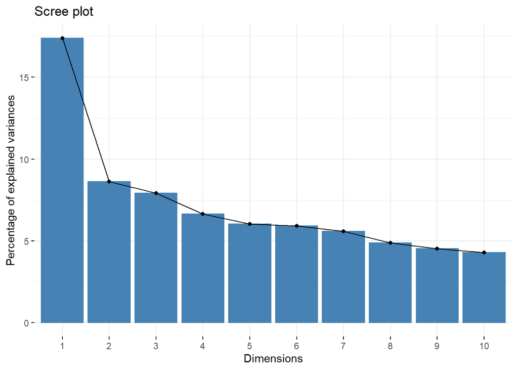

```r
fviz_screeplot(pca)
```

```r
#pcaCharts(pca)
```

**Inference: Top 20 predictors can explain more than 98% of variance**

```r
pcavar<-pca$sdev^2
pcasd<-pca$sdev
```

**check variance of first 20 components as per sumary**

```r
#pcavar[1:20]
prop_varex <- pcavar/sum(pcavar)
prop_varex[1:20]
```

```
##  [1] 0.17402475 0.08614958 0.07917839 0.06646966 0.06022429 0.05900978
##  [7] 0.05583944 0.04880134 0.04519660 0.04285651 0.03570555 0.03492360
## [13] 0.03410694 0.03113344 0.02842625 0.02573895 0.02497464 0.02154805
## [19] 0.02110303 0.01331661
```

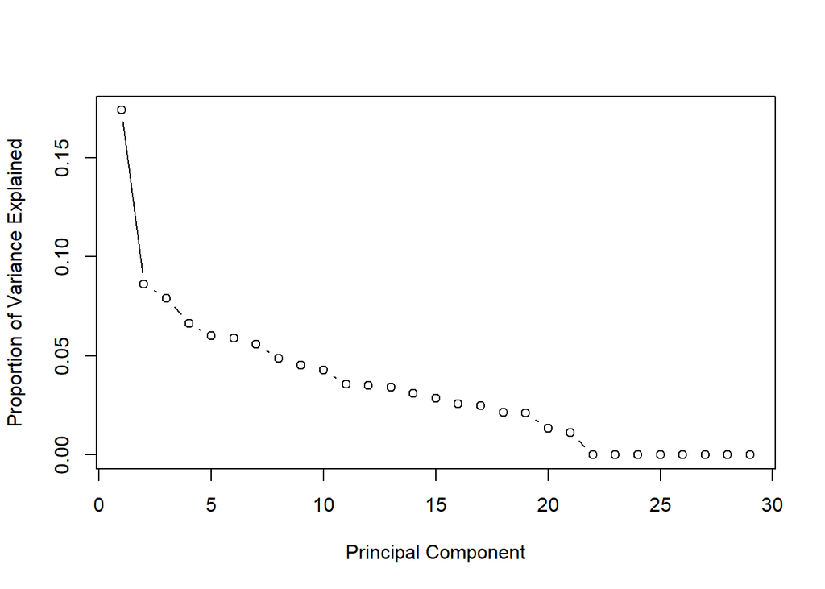

```r
#scree plot
plot(prop_varex, xlab = "Principal Component",
             ylab = "Proportion of Variance Explained",
             type = "b")
```

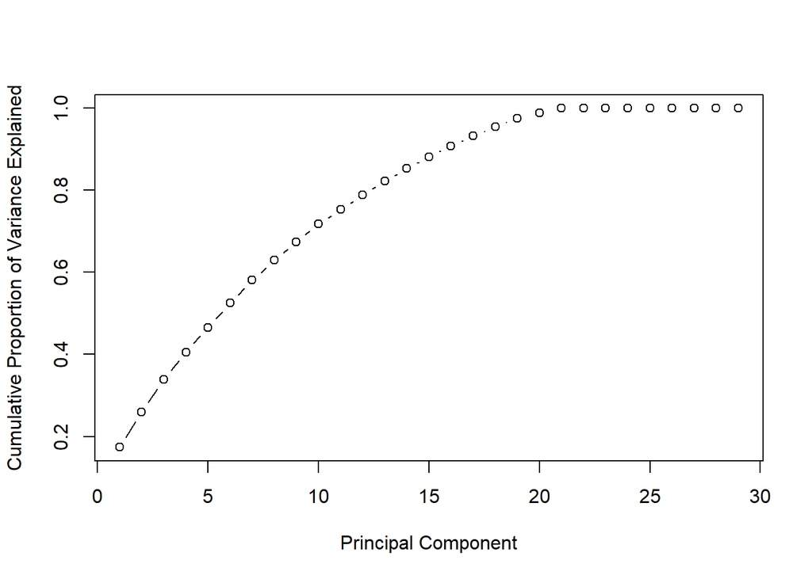

```r
#cumulative scree plot
plot(cumsum(prop_varex), xlab = "Principal Component",
              ylab = "Cumulative Proportion of Variance Explained",
              type = "b")
```

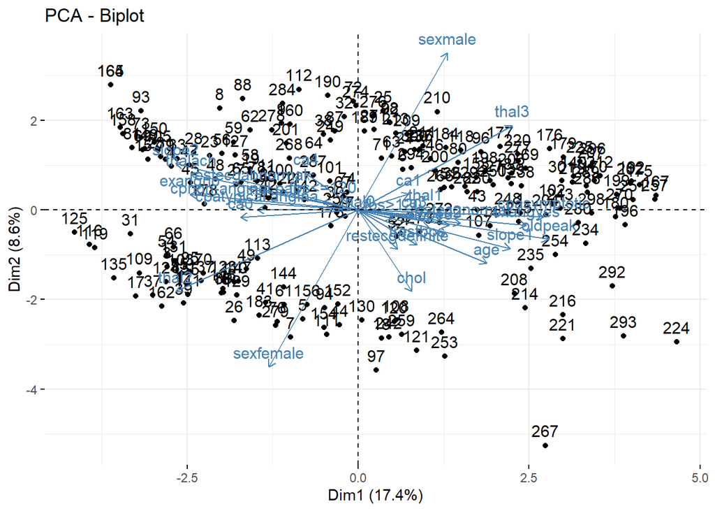

```r
fviz_pca(pca)
```

```r
#biplot(pca,scale=0, cex=.7)
```

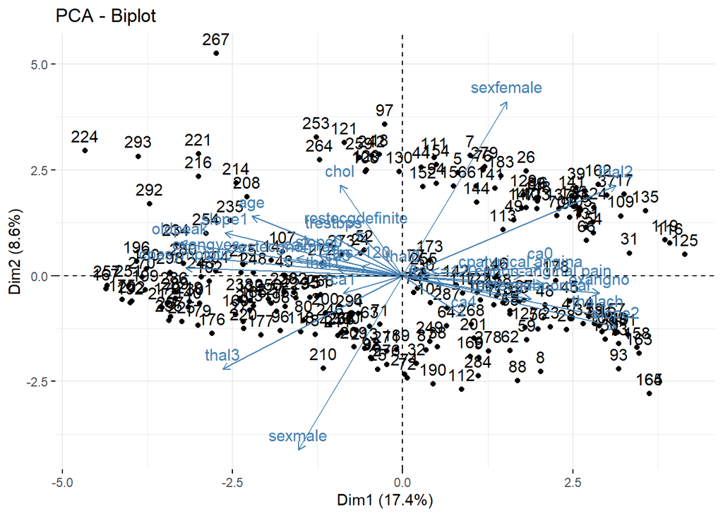

```r
pca.out <- pca
pca.out$rotation <- -pca.out$rotation
pca.out$x <- -pca.out$x
fviz_pca(pca.out)
```

```r
impPredictors<-rownames(data.frame(pca$rotation))[1:20]
notsoimp<-rownames(data.frame(pca$rotation))[21:29]
#[1:21]
```

```r
s_df <- apply(dt, 2, scale)
head(s_df)
```

```
##             age  sexfemale    sexmale cpasymptotic cpatypical angina
## [1,] -0.1470709 -0.6560432  0.6560432   -1.0760010        -0.4511991
## [2,] -1.2488032  1.5170999 -1.5170999   -1.0760010        -0.4511991
## [3,] -1.3589764 -0.6560432  0.6560432    0.9249833        -0.4511991
## [4,]  1.5055276 -0.6560432  0.6560432   -1.0760010        -0.4511991
## [5,]  0.4037953 -0.6560432  0.6560432    0.9249833        -0.4511991
## [6,]  0.4037953 -0.6560432  0.6560432    0.9249833        -0.4511991
##      cpnon-anginal pain    trestbps        chol   fbs<=120    fbs>120
## [1,]           1.551755 -0.06512095  0.07211863 -2.3661080  2.3661080
## [2,]           1.551755 -0.49320287 -0.62093350  0.4206414 -0.4206414
## [3,]          -0.641392  0.46998144 -0.34791296  0.4206414 -0.4206414
## [4,]           1.551755  2.61039102  0.66016286 -2.3661080  2.3661080
## [5,]          -0.641392 -0.17214143 -0.55792876  0.4206414 -0.4206414
## [6,]          -0.641392 -0.17214143  0.34513917  0.4206414 -0.4206414
##      restecgabnormal restecgdefinite restecgnormal     thalach   exangno
```

[output cut: 27 more lines]

```r
cov_df <- cov(s_df) #covariance metric
cov_df
```

```
##                            age    sexfemale      sexmale cpasymptotic
## age                 1.00000000  0.044895676 -0.044895676   0.21713321
## sexfemale           0.04489568  1.000000000 -1.000000000  -0.15281509
## sexmale            -0.04489568 -1.000000000  1.000000000   0.15281509
## cpasymptotic        0.21713321 -0.152815087  0.152815087   1.00000000
## cpatypical angina  -0.10551936  0.085711609 -0.085711609  -0.48779159
## cpnon-anginal pain -0.15088935  0.096743886 -0.096743886  -0.69340921
## trestbps            0.22722685  0.044151643 -0.044151643   0.10974448
## chol                0.27676712  0.231176419 -0.231176419   0.09868066
## fbs<=120           -0.14010101  0.018953785 -0.018953785   0.05834037
## fbs>120             0.14010101 -0.018953785  0.018953785  -0.05834037
## restecgabnormal    -0.13074969  0.102749367 -0.102749367  -0.17029702
## restecgdefinite     0.02333377  0.042114708 -0.042114708   0.09048279
## restecgnormal       0.12626084 -0.110911514  0.110911514   0.15283040
## thalach            -0.44668768  0.042165244 -0.042165244  -0.31587407
## exangno            -0.14455863  0.083958351 -0.083958351  -0.36730674
## exangyes            0.14455863 -0.083958351  0.083958351   0.36730674
## oldpeak             0.22217640 -0.101633444  0.101633444   0.39467060
## slope0              0.06180576 -0.061184697  0.061184697   0.13158849
## slope1              0.20711257 -0.007804844  0.007804844   0.25620000
## slope2             -0.23320834  0.034897564 -0.034897564  -0.31293916
## ca0                -0.33649460  0.094161419 -0.094161419  -0.16440288
## ca1                 0.17924800 -0.058737722  0.058737722  -0.02233923
## ca2                 0.25814376  0.007334288 -0.007334288   0.28649398
## ca3                 0.10816025 -0.072149276  0.072149276   0.02240201
## ca4                -0.15438162 -0.078785558  0.078785558  -0.12921915
## thal0              -0.01977525  0.042114708 -0.042114708  -0.00738635
## thal1               0.12299163 -0.125248528  0.125248528   0.15810851
## thal2              -0.18880235  0.415686404 -0.415686404  -0.32393904
## thal3               0.13705258 -0.373871529  0.373871529   0.25615387
##                    cpatypical angina cpnon-anginal pain     trestbps
## age                     -0.105519358        -0.15088935  0.227226847
## sexfemale                0.085711609         0.09674389  0.044151643
## sexmale                 -0.085711609        -0.09674389 -0.044151643
## cpasymptotic            -0.487791585        -0.69340921  0.109744476
## cpatypical angina        1.000000000        -0.29076701 -0.042324705
## cpnon-anginal pain      -0.290767011         1.00000000 -0.085348723
## trestbps                -0.042324705        -0.08534872  1.000000000
## chol                    -0.014909937        -0.09585064  0.173933079
## fbs<=120                 0.015228916        -0.07651301 -0.176015299
```

[output cut: 185 more lines]

```
## exangno             0.24662147 -0.24058775
## exangyes           -0.24662147  0.24058775
## oldpeak            -0.33111163  0.30531958
## slope0             -0.09319478  0.04202012
## slope1             -0.24423500  0.18537702
## slope2              0.28401846 -0.20283432
## ca0                 0.22433232 -0.20529474
## ca1                -0.09438695  0.13881823
## ca2                -0.17367550  0.12325894
## ca3                -0.11254013  0.06708632
## ca4                 0.10591451 -0.09140762
## thal0              -0.11039194 -0.07445609
## thal1              -0.28911934 -0.19500244
## thal2               1.00000000 -0.86303202
## thal3              -0.86303202  1.00000000
```

```r
ei_df <- eigen(cov_df)
ei_df
```

```
## eigen() decomposition
## $values
##  [1]  5.046718e+00  2.498338e+00  2.296173e+00  1.927620e+00  1.746504e+00
##  [6]  1.711284e+00  1.619344e+00  1.415239e+00  1.310701e+00  1.242839e+00
## [11]  1.035461e+00  1.012784e+00  9.891014e-01  9.028698e-01  8.243613e-01
## [16]  7.464296e-01  7.242646e-01  6.248935e-01  6.119878e-01  3.861818e-01
## [21]  3.269050e-01  2.091888e-16  2.024479e-17  1.676868e-17 -2.500649e-17
## [26] -3.572164e-17 -1.549294e-16 -2.823622e-16 -3.844234e-16
##
## $vectors
##                [,1]          [,2]         [,3]        [,4]        [,5]
##  [1,] -0.2040227737  1.833293e-01 -0.094779873 -0.13731378  0.10549430
##  [2,]  0.1413086011  5.394177e-01  0.039906990 -0.10547773  0.06696998
##  [3,] -0.1413086011 -5.394177e-01 -0.039906990  0.10547773 -0.06696998
##  [4,] -0.2942003135  2.461245e-02  0.124389538  0.04018123 -0.01260643
```

[output cut: 175 more lines]

```r
str(ei_df)
```

```
## List of 2
##  $ values : num [1:29] 5.05 2.5 2.3 1.93 1.75 ...
##  $ vectors: num [1:29, 1:29] -0.204 0.141 -0.141 -0.294 0.16 ...
##  - attr(*, "class")= chr "eigen"
```

```r
ei_df$vectors[,1:21]
```

```
##                [,1]          [,2]         [,3]        [,4]        [,5]
##  [1,] -0.2040227737  1.833293e-01 -0.094779873 -0.13731378  0.10549430
##  [2,]  0.1413086011  5.394177e-01  0.039906990 -0.10547773  0.06696998
##  [3,] -0.1413086011 -5.394177e-01 -0.039906990  0.10547773 -0.06696998
##  [4,] -0.2942003135  2.461245e-02  0.124389538  0.04018123 -0.01260643
##  [5,]  0.1600597333  5.511576e-06 -0.032650698  0.05734463  0.17794918
##  [6,]  0.1903397143 -2.698063e-02 -0.109385163 -0.09137243 -0.13306274
##  [7,] -0.0935479157  1.204104e-01 -0.222487435  0.12005801 -0.05039087
##  [8,] -0.0849067274  2.803531e-01  0.029034968  0.08955058  0.10490839
##  [9,]  0.0554027651 -2.904020e-02  0.591801533  0.18297854 -0.01650000
## [10,] -0.0554027651  2.904020e-02 -0.591801533 -0.18297854  0.01650000
## [11,]  0.1736418581 -7.301015e-02  0.134795878 -0.54120573 -0.24450421
## [12,] -0.0625879247  1.361349e-01  0.006726700  0.07124934 -0.29057685
## [13,] -0.1615699524  4.669831e-02 -0.136120641  0.52752438  0.30073749
## [14,]  0.2642768993 -1.226385e-01 -0.027373082  0.15232430  0.06430739
```

[output cut: 135 more lines]

```r
p <- ei_df$vectors[,1:21]
p <- -p
p
```

```
##                [,1]          [,2]         [,3]        [,4]        [,5]
##  [1,]  0.2040227737 -1.833293e-01  0.094779873  0.13731378 -0.10549430
##  [2,] -0.1413086011 -5.394177e-01 -0.039906990  0.10547773 -0.06696998
##  [3,]  0.1413086011  5.394177e-01  0.039906990 -0.10547773  0.06696998
##  [4,]  0.2942003135 -2.461245e-02 -0.124389538 -0.04018123  0.01260643
##  [5,] -0.1600597333 -5.511576e-06  0.032650698 -0.05734463 -0.17794918
##  [6,] -0.1903397143  2.698063e-02  0.109385163  0.09137243  0.13306274
##  [7,]  0.0935479157 -1.204104e-01  0.222487435 -0.12005801  0.05039087
##  [8,]  0.0849067274 -2.803531e-01 -0.029034968 -0.08955058 -0.10490839
##  [9,] -0.0554027651  2.904020e-02 -0.591801533 -0.18297854  0.01650000
## [10,]  0.0554027651 -2.904020e-02  0.591801533  0.18297854 -0.01650000
## [11,] -0.1736418581  7.301015e-02 -0.134795878  0.54120573  0.24450421
## [12,]  0.0625879247 -1.361349e-01 -0.006726700 -0.07124934  0.29057685
## [13,]  0.1615699524 -4.669831e-02  0.136120641 -0.52752438 -0.30073749
## [14,] -0.2642768993  1.226385e-01  0.027373082 -0.15232430 -0.06430739
```

[output cut: 135 more lines]

```r
# explainable variance ratio
avo <- ei_df$values / sum(ei_df$values)
round(avo, 4)
```

```
##  [1] 0.1740 0.0861 0.0792 0.0665 0.0602 0.0590 0.0558 0.0488 0.0452 0.0429
## [11] 0.0357 0.0349 0.0341 0.0311 0.0284 0.0257 0.0250 0.0215 0.0211 0.0133
## [21] 0.0113 0.0000 0.0000 0.0000 0.0000 0.0000 0.0000 0.0000 0.0000
```

```r
sum(avo[1:31])
```

```
## [1] NA
```

## 7.0 Supervised Learning

### 7.1 Logistic Regression

```r
# Creating full(including all varibales) and null(intercept only) models for d_1
logit_full = glm(heart_disease~., data = data, family = binomial)
logit_null = glm(heart_disease~1, data = data, family = binomial)


# Forward selection procedure
forward = step(logit_null, scope = list(lower = logit_null, upper = logit_full), direction = "forward")
```

```
## Start:  AIC=288.3
## heart_disease ~ 1
##
##            Df Deviance    AIC
## + thal      3   227.45 235.45
## + ca        4   231.45 241.45
## + oldpeak   1   243.02 247.02
## + cp        2   243.35 249.35
## + thalach   1   251.58 255.58
## + slope     2   255.91 261.91
## + exang     1   262.64 266.64
## + sex       1   269.75 273.75
## + age       1   271.15 275.15
## + restecg   2   274.01 280.01
## + chol      1   278.52 282.52
## + trestbps  1   283.38 287.38
## <none>          286.30 288.30
## + fbs       1   286.14 290.14
##
## Step:  AIC=235.45
## heart_disease ~ thal
##
##            Df Deviance    AIC
## + ca        4   186.85 202.85
## + oldpeak   1   204.19 214.19
## + thalach   1   204.24 214.24
## + cp        2   202.45 214.45
## + slope     2   209.78 221.78
## + exang     1   215.21 225.21
## + age       1   218.07 228.07
## + chol      1   218.62 228.62
## + restecg   2   216.67 228.67
## <none>          227.45 235.45
## + sex       1   226.23 236.23
## + trestbps  1   226.51 236.51
## + fbs       1   227.44 237.44
##
## Step:  AIC=202.85
## heart_disease ~ thal + ca
##
```

[output cut: 68 more lines]

```
## + trestbps  1   146.31 174.31
## + age       1   147.07 175.07
## + fbs       1   147.53 175.53
##
## Step:  AIC=172.55
## heart_disease ~ thal + ca + cp + thalach + chol + sex + oldpeak
##
##            Df Deviance    AIC
## <none>          144.55 172.55
## + slope     2   141.03 173.03
## + exang     1   143.15 173.15
## + trestbps  1   143.63 173.63
## + age       1   144.16 174.16
## + restecg   2   142.16 174.16
## + fbs       1   144.27 174.27
```

```r
# Backward selection procedure
backward = step(logit_full, scope = list(lower = logit_null, upper = logit_full), direction = "backward")
```

```
## Start:  AIC=179.49
## heart_disease ~ age + sex + cp + trestbps + chol + fbs + restecg +
##     thalach + exang + oldpeak + slope + ca + thal
##
##            Df Deviance    AIC
## - restecg   2   137.03 177.03
## - oldpeak   1   135.76 177.76
## - fbs       1   136.03 178.03
## - age       1   136.26 178.26
## - trestbps  1   136.85 178.85
## - slope     2   138.93 178.93
## - exang     1   137.09 179.09
## - cp        2   139.42 179.42
## <none>          135.49 179.49
## - thalach   1   139.61 181.61
## - chol      1   140.91 182.91
## - sex       1   141.86 183.86
## - thal      3   150.43 188.43
## - ca        4   162.40 198.40
##
## Step:  AIC=177.03
## heart_disease ~ age + sex + cp + trestbps + chol + fbs + thalach +
##     exang + oldpeak + slope + ca + thal
##
##            Df Deviance    AIC
## - oldpeak   1   137.58 175.58
## - fbs       1   137.61 175.61
## - age       1   137.96 175.96
## - exang     1   138.60 176.60
## - slope     2   140.61 176.61
## - cp        2   140.93 176.93
## <none>          137.03 177.03
## - trestbps  1   139.06 177.06
## - thalach   1   141.62 179.62
## - chol      1   143.73 181.73
## - sex       1   143.85 181.85
## - thal      3   151.11 185.11
## - ca        4   164.23 196.23
##
## Step:  AIC=175.58
```

[output cut: 62 more lines]

```
## - thal     3   156.11 182.11
## - ca       4   170.18 194.18
##
## Step:  AIC=172.61
## heart_disease ~ sex + cp + chol + thalach + slope + ca + thal
##
##           Df Deviance    AIC
## <none>         142.61 172.61
## - slope    2   147.64 173.64
## - thalach  1   147.53 175.53
## - cp       2   150.23 176.23
## - sex      1   148.72 176.72
## - chol     1   150.41 178.41
## - thal     3   159.14 183.14
## - ca       4   171.37 193.37
```

```r
# Both
both = step(logit_full, scope = list(lower = logit_null, upper = logit_full), direction = "both")
```

```
## Start:  AIC=179.49
## heart_disease ~ age + sex + cp + trestbps + chol + fbs + restecg +
##     thalach + exang + oldpeak + slope + ca + thal
##
##            Df Deviance    AIC
## - restecg   2   137.03 177.03
## - oldpeak   1   135.76 177.76
## - fbs       1   136.03 178.03
## - age       1   136.26 178.26
## - trestbps  1   136.85 178.85
## - slope     2   138.93 178.93
## - exang     1   137.09 179.09
## - cp        2   139.42 179.42
## <none>          135.49 179.49
## - thalach   1   139.61 181.61
## - chol      1   140.91 182.91
## - sex       1   141.86 183.86
## - thal      3   150.43 188.43
## - ca        4   162.40 198.40
##
## Step:  AIC=177.03
## heart_disease ~ age + sex + cp + trestbps + chol + fbs + thalach +
##     exang + oldpeak + slope + ca + thal
##
##            Df Deviance    AIC
## - oldpeak   1   137.58 175.58
## - fbs       1   137.61 175.61
## - age       1   137.96 175.96
## - exang     1   138.60 176.60
## - slope     2   140.61 176.61
## - cp        2   140.93 176.93
## <none>          137.03 177.03
## - trestbps  1   139.06 177.06
## + restecg   2   135.49 179.49
## - thalach   1   141.62 179.62
## - chol      1   143.73 181.73
## - sex       1   143.85 181.85
## - thal      3   151.11 185.11
## - ca        4   164.23 196.23
##
```

[output cut: 83 more lines]

```
##            Df Deviance    AIC
## <none>          142.61 172.61
## + exang     1   140.80 172.80
## + oldpeak   1   141.03 173.03
## + trestbps  1   141.22 173.22
## + restecg   2   139.57 173.57
## - slope     2   147.64 173.64
## + age       1   141.91 173.91
## + fbs       1   142.47 174.47
## - thalach   1   147.53 175.53
## - cp        2   150.23 176.23
## - sex       1   148.72 176.72
## - chol      1   150.41 178.41
## - thal      3   159.14 183.14
## - ca        4   171.37 193.37
```

```r
forward$formula
```

```
## heart_disease ~ thal + ca + cp + thalach + chol + sex + oldpeak
```

Logistic model

```r
logistic_model = glm(forward$formula, data=data, family = binomial)
summary(logistic_model)
```

```
##
## Call:
## glm(formula = forward$formula, family = binomial, data = data)
##
## Deviance Residuals:
##     Min       1Q   Median       3Q      Max
## -2.3951  -0.4321   0.1993   0.4786   2.5288
##
## Coefficients:
##                      Estimate Std. Error z value Pr(>|z|)
## (Intercept)        -1.828e-02  2.429e+00  -0.008 0.993996
## thal1               2.788e+00  1.843e+00   1.513 0.130229
## thal2               2.772e+00  1.677e+00   1.653 0.098311 .
## thal3               1.006e+00  1.685e+00   0.597 0.550386
## ca1                -1.375e+00  5.520e-01  -2.491 0.012729 *
## ca2                -2.773e+00  7.354e-01  -3.771 0.000163 ***
## ca3                -2.617e+00  1.090e+00  -2.401 0.016329 *
## ca4                 1.256e+01  1.370e+03   0.009 0.992683
## cpatypical angina   1.061e+00  6.670e-01   1.591 0.111692
## cpnon-anginal pain  1.282e+00  5.515e-01   2.325 0.020073 *
## thalach             2.490e-02  1.076e-02   2.314 0.020651 *
## chol               -1.457e-02  5.227e-03  -2.788 0.005300 **
## sexmale            -1.470e+00  6.368e-01  -2.308 0.020996 *
## oldpeak            -4.030e-01  2.325e-01  -1.733 0.083100 .
## ---
## Signif. codes:  0 '***' 0.001 '**' 0.01 '*' 0.05 '.' 0.1 ' ' 1
##
## (Dispersion parameter for binomial family taken to be 1)
##
##     Null deviance: 286.30  on 211  degrees of freedom
## Residual deviance: 144.55  on 198  degrees of freedom
## AIC: 172.55
##
## Number of Fisher Scoring iterations: 15
```

```r
backward$formula
```

```
## heart_disease ~ sex + cp + chol + thalach + slope + ca + thal
```

```r
both$formula
```

```
## heart_disease ~ sex + cp + chol + thalach + slope + ca + thal
```

**Symmetric Cost Logistic Regression**

```r
# predicting on train set
predict_logit_train <- predict(logistic_model, type="response")


costfunc = function(obs, pred.p,pcut){
  weight1 = 1   # define the weight for "true=1 but pred=0" (FN)
  weight0 = 1    # define the weight for "true=0 but pred=1" (FP)
  c1 = (obs==1)&(pred.p<pcut)    # count for "true=1 but pred=0"   (FN)
  c0 = (obs==0)&(pred.p>=pcut)   # count for "true=0 but pred=1"   (FP)
  cost = mean(weight1*c1 + weight0*c0)  # misclassification with weight
  return(cost) # you have to return to a value when you write R functions
}

# define a sequence from 0.01 to 1 by 0.01
p.seq = seq(0.01, 1, 0.01)


cost = rep(0, length(p.seq))
for(i in 1:length(p.seq)){
  cost[i] = costfunc(obs = data$heart_disease, pred.p = predict_logit_train, pcut = p.seq[i])
} # end of the loop

optimal.pcut.sym = p.seq[which(cost==min(cost))][1]

optimal.pcut.sym  ##0.42
```

```
## [1] 0.42
```

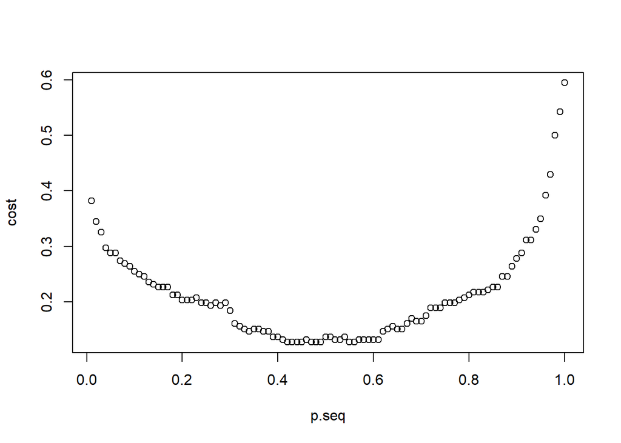

```r
plot(p.seq, cost)
```

```r
#predict the response
pred_train <- predict(logistic_model, type = "response")
#convert to binary based on optimal pcut for sym
pred.train.sym <- as.numeric(pred_train > optimal.pcut.sym)

confusion_matrix_train_sym <- table(data$heart_disease, pred.train.sym,dnn =c('true','predicted'))
confusion_matrix_train_sym
```

```
##     predicted
## true   0   1
##    0  67  19
##    1   8 118
```

```r
misclassification_rate_train_sym <- round((confusion_matrix_train_sym[2]+confusion_matrix_train_sym[3])/sum(confusion_matrix_train_sym), 2)
cat("train misclassfication rate:", misclassification_rate_train_sym)
```

```
## train misclassfication rate: 0.13
```

```r
#Symmetric cost evaluation function
cost0 <- function(r, pi){
  weight1 = 1
  weight0 = 1
  c1 = (r==1)&(pi==0) #logical vector - true if actual 1 but predict 0
  c0 = (r==0)&(pi==1) #logical vector - true if actual 0 but predict 1
  return(mean(weight1*c1+weight0*c0))
}

#Aymmetric cost evaluation function
cost1 <- function(r, pi){
  weight1 = 5
  weight0 = 1
  c1 = (r==1)&(pi==0) #logical vector - true if actual 1 but predict 0
  c0 = (r==0)&(pi==1) #logical vector - true if actual 0 but predict 1
  return(mean(weight1*c1+weight0*c0))
}
```

**In sample- symmetric**

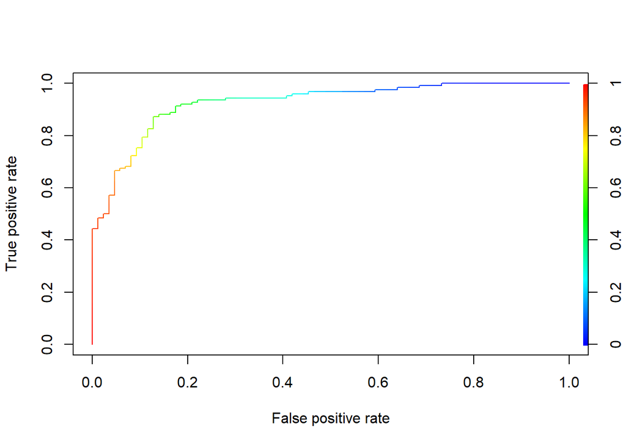

```r
#LOSS
LOSS=(insamplecost0<-cost0(data$heart_disease,pred.train.sym))
#Misclassification rate
MCR=(insampleMCR0<-mean(data$heart_disease!=pred.train.sym))

#Roc curve | AUC
pred <- prediction(as.numeric(pred_train),as.numeric(data$heart_disease))
perf <- performance(pred, "tpr", "fpr")
plot(perf, colorize=TRUE)
```

```r
#Get the AUC
AUC=unlist(slot(performance(pred, "auc"), "y.values"))

rslt_sym_in<-c(LOSS,MCR,AUC)
rslt_sym_in
```

```
## [1] 0.1273585 0.1273585 0.9262643
```

**Optimal pcut - Assymetric Cost Logistic Regression**

```r
costfuncasym = function(obs, pred.p,pcut){
  weight1 = 5   # define the weight for "true=1 but pred=0" (FN)
  weight0 = 1    # define the weight for "true=0 but pred=1" (FP)
  c1 = (obs==1)&(pred.p<pcut)    # count for "true=1 but pred=0"   (FN)
  c0 = (obs==0)&(pred.p>=pcut)   # count for "true=0 but pred=1"   (FP)
  cost = mean(weight1*c1 + weight0*c0)  # misclassification with weight
  return(cost) # you have to return to a value when you write R functions
} # end of the function

p.seq = seq(0.01, 1, 0.01)
cost = rep(0, length(p.seq))
for(i in 1:length(p.seq)){
  cost[i] = costfuncasym(obs = data$heart_disease, pred.p = predict_logit_train, pcut = p.seq[i])
} # end of the loop

optimal.pcut.asym = p.seq[which(cost==min(cost))][1]

optimal.pcut.asym #0.2
```

```
## [1] 0.2
```

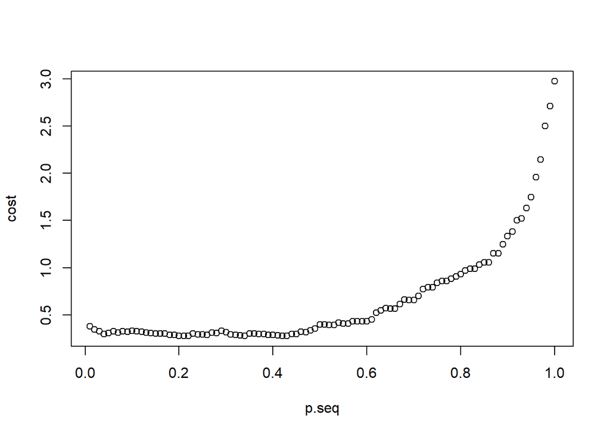

```r
plot(p.seq, cost)
```

```r
pred_train <- predict(logistic_model, type = "response")
pred.train.asym <- as.numeric(pred_train > optimal.pcut.asym)


confusion_matrix_train_asym <- table(data$heart_disease, pred.train.asym, dnn =c('true','predicted'))
confusion_matrix_train_asym
```

```
##     predicted
## true   0   1
##    0  47  39
##    1   4 122
```

```r
misclassification_rate_train_asym <- round((confusion_matrix_train_asym[2]+confusion_matrix_train_asym[3])/sum(confusion_matrix_train_asym), 2)
cat("train Asymmetric misclassfication rate:", misclassification_rate_train_asym)
```

```
## train Asymmetric misclassfication rate: 0.2
```

**In sample - asymmetric**

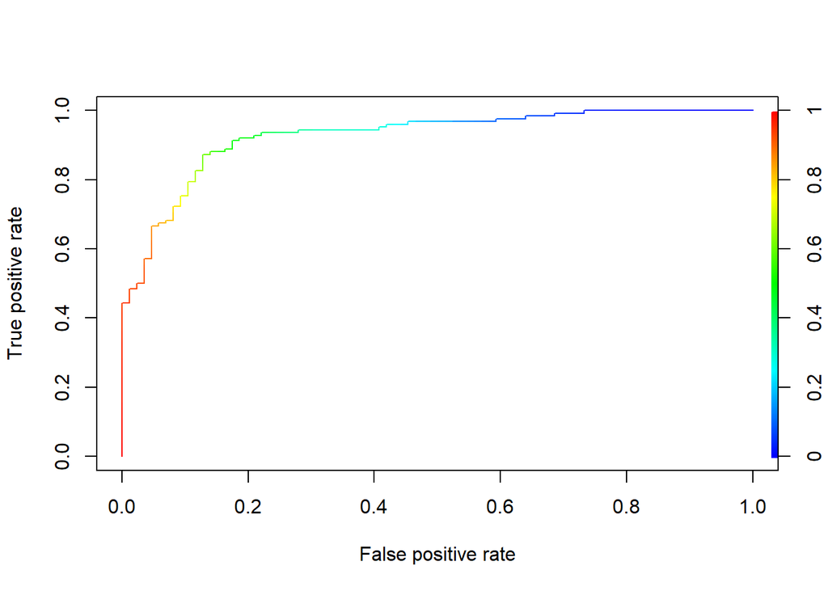

```r
#LOSS
LOSS=(insamplecost1<-cost1(data$heart_disease,pred.train.asym))
#Misclassification rate
MCR=(insampleMCR1<-mean(data$heart_disease!=pred.train.asym))

#Roc curve | AUC
pred <- prediction(as.numeric(pred_train),as.numeric(data$heart_disease))
perf <- performance(pred, "tpr", "fpr")
plot(perf, colorize=TRUE)
```

```r
#Get the AUC
AUC=unlist(slot(performance(pred, "auc"), "y.values"))

rslt_asym_in<-c(LOSS,MCR,AUC)
rslt_asym_in
```

```
## [1] 0.2783019 0.2028302 0.9262643
```

**Out sample - symmetric**

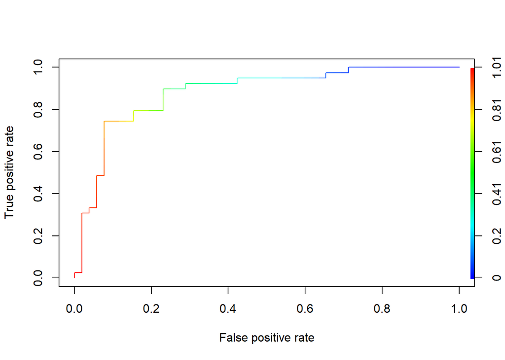

```r
#predict the response
pred_test <- predict(logistic_model,newdata=data_test, type = "response")
#convert to binary based on optimal pcut for sym
pred.test.sym <- as.numeric(pred_test > optimal.pcut.sym)
#LOSS
LOSS=(outsamplecost0<-cost0(data_test$heart_disease,pred.test.sym))
#Misclassification rate
MCR=(outsampleMCR0<-mean(data_test$heart_disease!=pred.test.sym))

#Roc curve | AUC
pred <- prediction(as.numeric(pred_test),as.numeric(data_test$heart_disease))
perf <- performance(pred, "tpr", "fpr")
plot(perf, colorize=TRUE)
```

```r
#Get the AUC
AUC=unlist(slot(performance(pred, "auc"), "y.values"))

rslt_sym_out<-c(LOSS,MCR,AUC)
rslt_sym_out
```

```
## [1] 0.1758242 0.1758242 0.8801775
```

**Out sample - asymmetric**

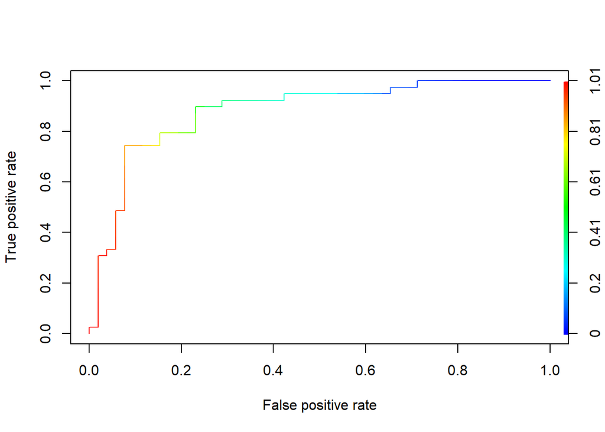

```r
#convert to binary based on optimal pcut for sym
pred.test.asym <- as.numeric(pred_test > optimal.pcut.asym)
#LOSS
LOSS=(outsamplecost1<-cost1(data_test$heart_disease,pred.test.asym))
#Misclassification rate
MCR=(outsampleMCR1<-mean(data_test$heart_disease!=pred.test.asym))

#Roc curve | AUC
pred <- prediction(as.numeric(pred_test),as.numeric(data_test$heart_disease))
perf.l<- performance(pred, "tpr", "fpr")
plot(perf.l, colorize=TRUE)
```

```r
#Get the AUC
AUC=unlist(slot(performance(pred, "auc"), "y.values"))

rslt_asym_out<-c(LOSS,MCR,AUC)
rslt_asym_out
```

```
## [1] 0.4175824 0.3296703 0.8801775
```

```r
eval<-data.frame(rbind(rslt_sym_in,rslt_sym_out,rslt_asym_in,rslt_asym_out),
                 row.names=c('Logistic - Symmetric cost : in_sample',
                             'Logistic - Symmetric cost : out_sample',
                             'Logistic - Asymmetric cost: in_sample',
                             'Logistic - Asymmetric cost : out_sample'))
colnames(eval) <- c("COST", "MCR","AUC")



kable(eval)  %>%
  kable_styling(bootstrap_options = c("striped", "hover", "responsive"),
                font_size = 12, position = "left", full_width = FALSE)
```

|  | COST | MCR | AUC |
| --- | --- | --- | --- |
| Logistic - Symmetric cost : in_sample | 0.1273585 | 0.1273585 | 0.9262643 |
| Logistic - Symmetric cost : out_sample | 0.1758242 | 0.1758242 | 0.8801775 |
| Logistic - Asymmetric cost: in_sample | 0.2783019 | 0.2028302 | 0.9262643 |
| Logistic - Asymmetric cost : out_sample | 0.4175824 | 0.3296703 | 0.8801775 |